# ——观察数据，确定研究问题

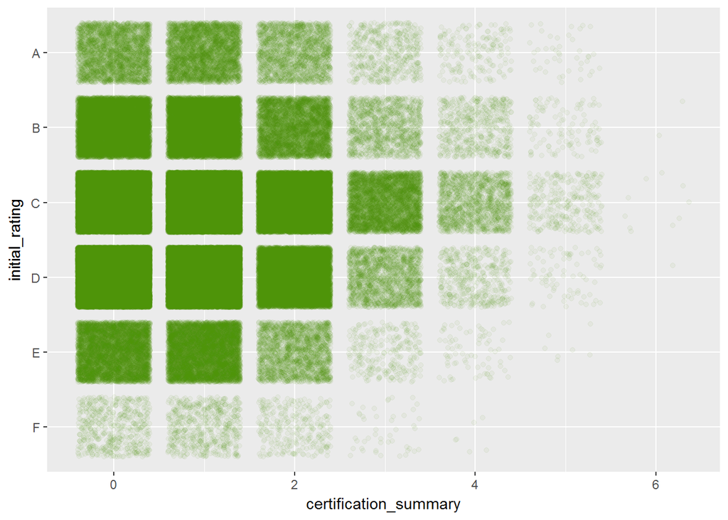

结论：  
借款利率与认证数量有比较微弱的负相关性，认证数量越多，借款利率越低，相关系数-0.156。  
从图上看，认证数量越多，初始评级在低评级的数量越少。观察认为：认证数量与初始评级存在认证数量越多，初始评级越高的关系，认证数量是初始评级的一个评判因素。  
**10**

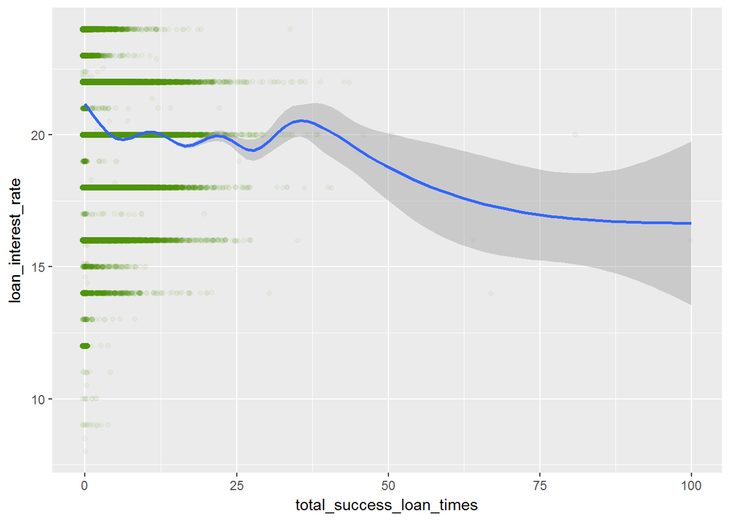

结论：借款次数和借款利率总体负相关，借款次数越多，借款利率越低，相关系数-0.22。  
**11**

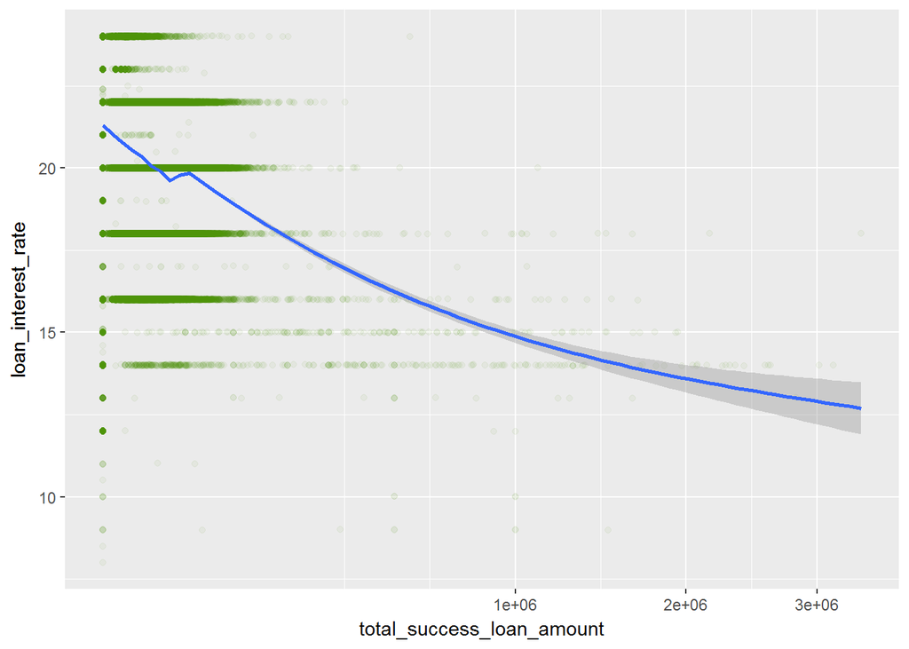

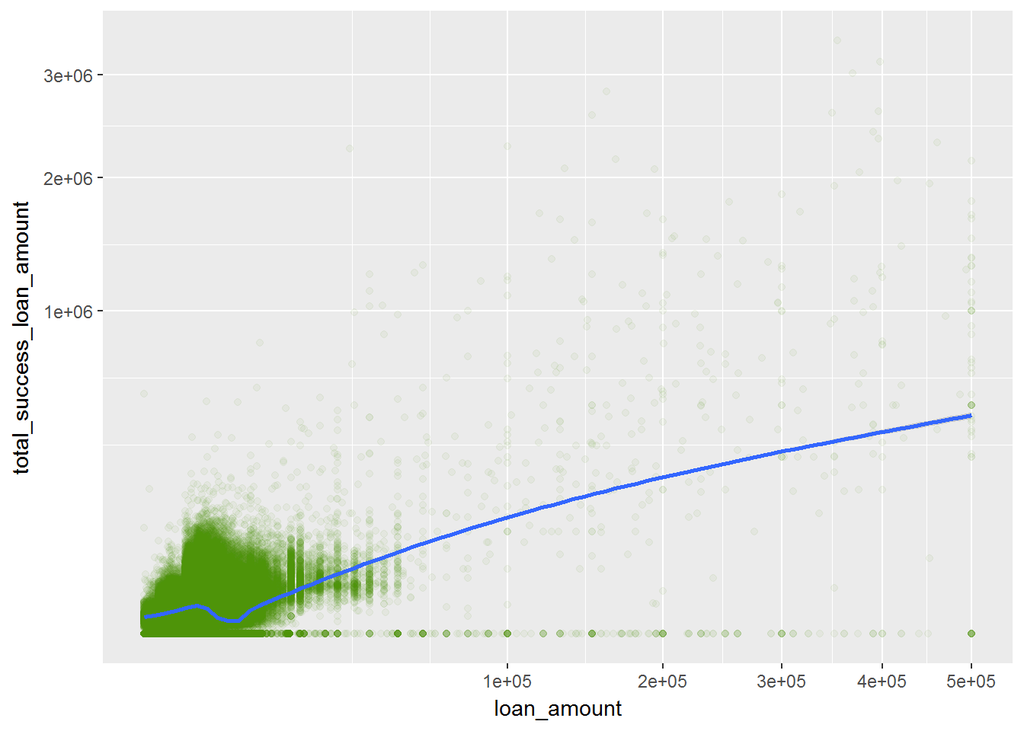

结论：  
历史成功借款金额和借款利率总体呈微弱负相关，相关系数-0.148。借款利率随历史成功借款金额的增加而降低。  
借款金额和历史成功借款金额正相关，相关系数0.557。  
**12**

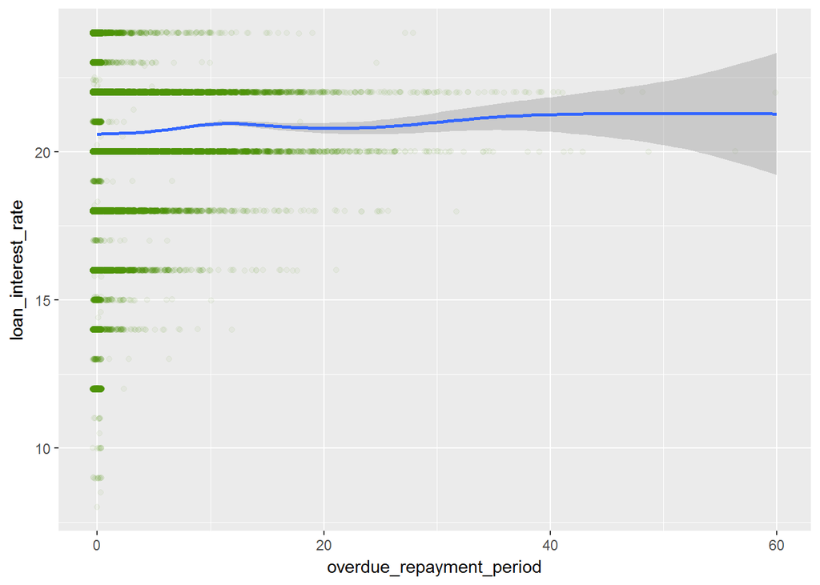

结论：历史逾期还款期数和借款利率无关  
**13**

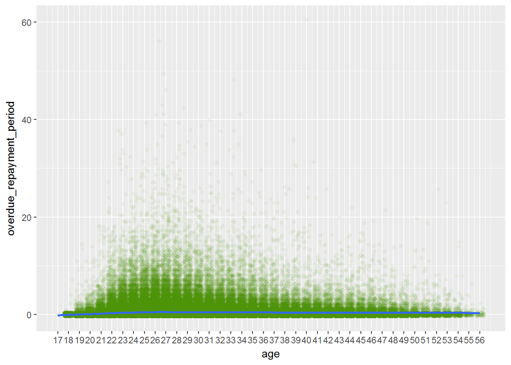

结论：年龄在23至34左右，逾期还款的数量较多，逾期时间更长。借款人的年龄也是在21至30岁左右最为集中。认为年龄与逾期还款无关，只是此年龄段人数更多，异常值的范围和概率也更大。

# ——双变量分析

### 探讨你在这部分探究中观察到的一些关系。这些感兴趣的特性与数据集内其他特性有什么区别？

通过观察__1__图相关系数和序号所代表的图：  
**2**  
结论：借款金额和借款利率总体呈微弱负相关，相关系数-0.148。借款金额在5000以内时，借款利率几乎没有相关性，借款金额超过5000以后，借款金额越多，借款利率越低，借款利率随借款金额的增加呈快速降低趋势。  
**3**  
结论：借款利率与借款成功的时间在2015年至2016年7月期间观察几乎没有变化，但是从2016年8月起至2017年1月，借款利率在最高档24%成交的借款人明显变少。  
**4**  
结论：虽然借款利率与借款期限总体相关系数0.378，观察上图，借款利率与借款期限并没有稳定的线性相关性。  
**5**  
结论：大部分的情况下，初始评级越低，借款利率越高。  
**6**  
结论：电商借款类型的借款利率最低。电商借款类型的初始评级集中在B和C，由于初始评级和借款利率的关系为比较强的负相关，初始评级比较高，借款利率会比较低，推断此为电商借款类型的借款利率最低的原因。  
**7**  
结论：首标的借款利率中位数要高于非首标的借款利率中位数约2%。认为是非首标借款用户对于投资用户来说，信任度更高，给的借款利率会低一些。  
**8**  
结论：借款利率与年龄没有相关性  
**9**  
结论：  
借款利率与认证数量有比较微弱的负相关性，认证数量越多，借款利率越低，相关系数-0.156。  
从图上看，认证数量越多，初始评级在低评级的数量越少。观察认为：认证数量与初始评级存在认证数量越多，初始评级越高的关系，认证数量是初始评级的一个评判因素。  
**10**  
结论：借款次数和借款利率总体负相关，借款次数越多，借款利率越低，相关系数-0.22。  
**11**  
结论：  
历史成功借款金额和借款利率总体呈微弱负相关，相关系数-0.148。借款利率随历史成功借款金额的增加而降低。  
借款金额和历史成功借款金额正相关，相关系数0.557。  
**12**  
结论：历史逾期还款期数和借款利率无关  
**13**  
结论：年龄在23至34左右，逾期还款的数量较多，逾期时间更长。借款人的年龄也是在21至30岁左右最为集中。认为年龄与逾期还款无关，只是此年龄段人数更多，异常值的范围和概率也更大。  
感兴趣的特性一般与借款利率相关，借款利率是借款人和投资人最关心的特性，是拍拍贷数据的核心指标。

### 你是否观察到主要特性与其他特性之间的有趣关系？

与借款利率关系最紧密的特性是初始评级。  
从图上看，借款类型、认证数量对借款利率的也有影响，主要原因是借款类型、认证数量与初始评级的关系较强，影响借款利率的其实是初始评级。  
借款金额、借款期限、借款成功时间、是否为首标、借款次数都在一定程度上对借款利率有一定影响，影响比较微弱。

### 你发现最强的关系是什么？

# ——多变量绘图选择

**1**

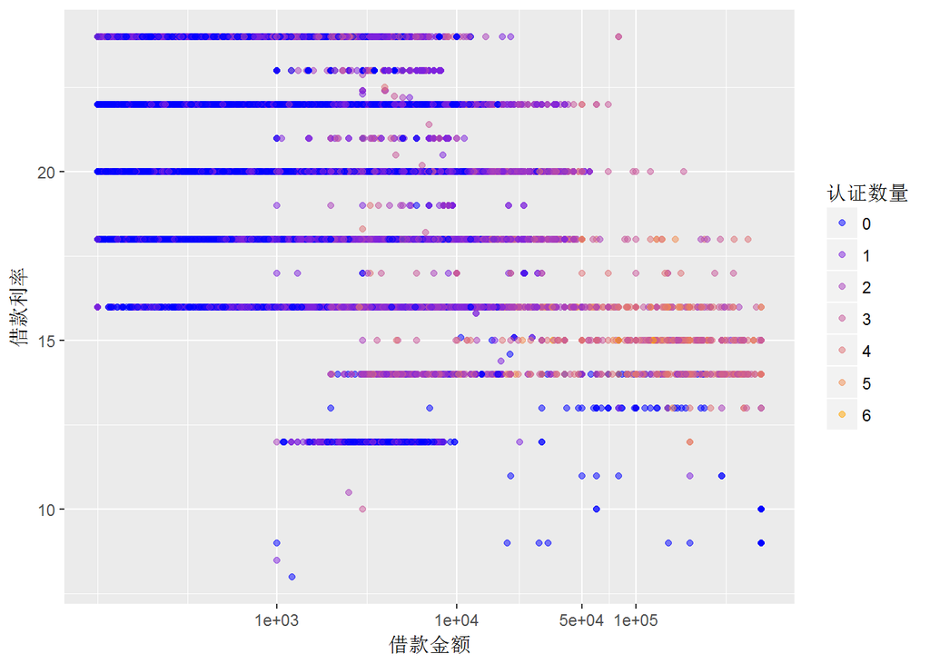

结论：  
随着借款金额的增大，借款利率降低。认证数量越多，借款利率越低。  
**2**

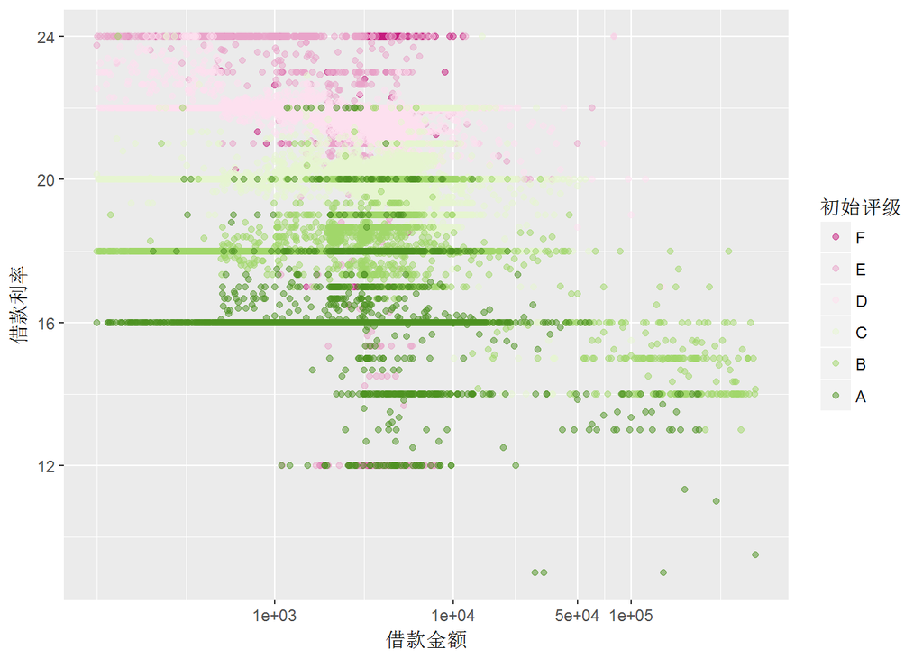

结论：  
随着借款金额的增大，借款利率降低。初始评级越高，借款利率越低。  
初始评级为A、B的借款人，借款金额在超过5万元左右时，利率会下降约2%-3%。  
初始评级为C、D、E、F的借款人，借款金额在超过5万元的借款人数量比较少，估计可能的原因是信用评级不够高，相对比较大金额的借款成功率下降。由于数据点较少，利率在借款金额超过5万元时，会下降约2%-3%的变化趋势不明显。  
**3**

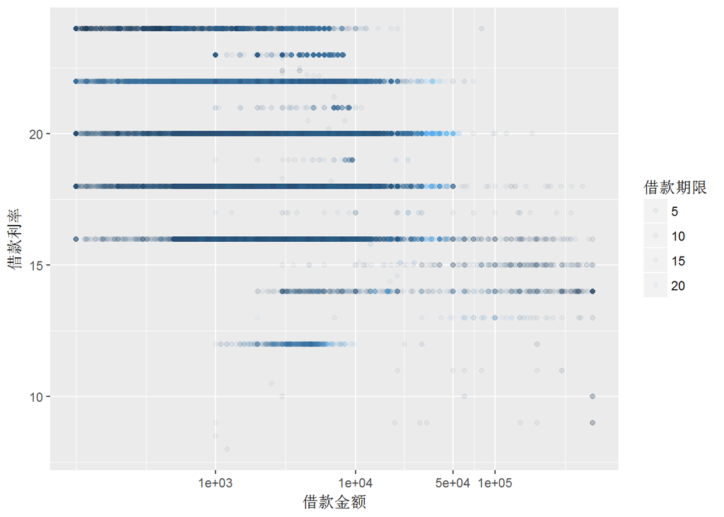

结论：借款期限与借款利率关系不大。从此图也能看出，借款金额在超过5万元时，借款利率有比较明显的降低趋势。借款金额在超过5万元时，借款利率比较集中在14%-16%。  
**4**

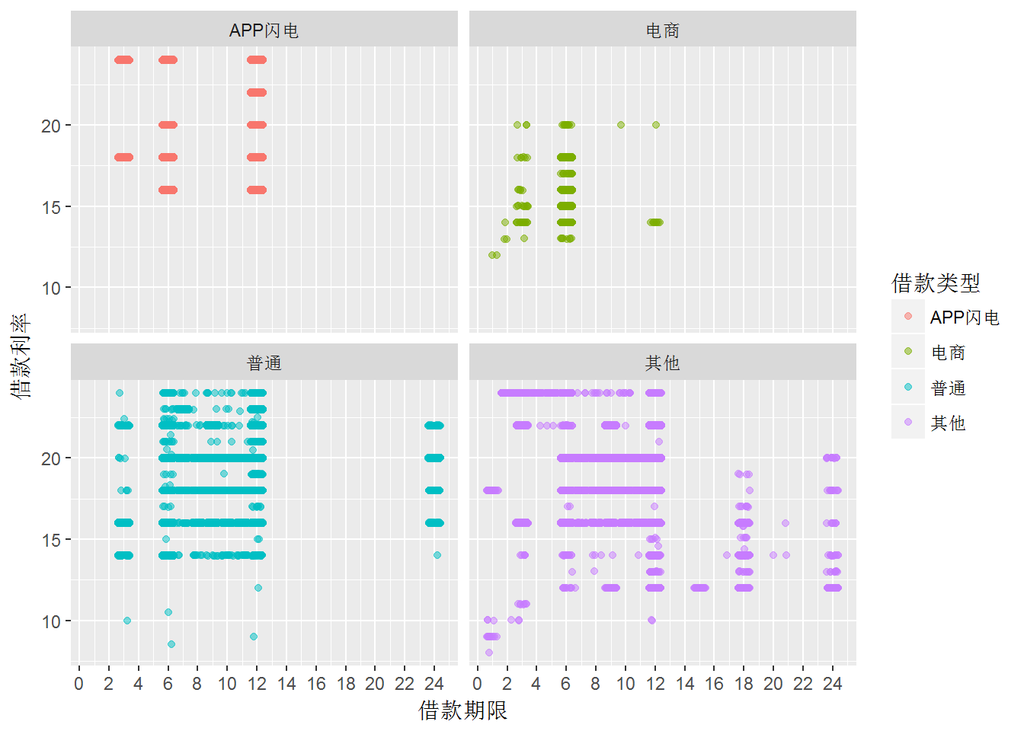

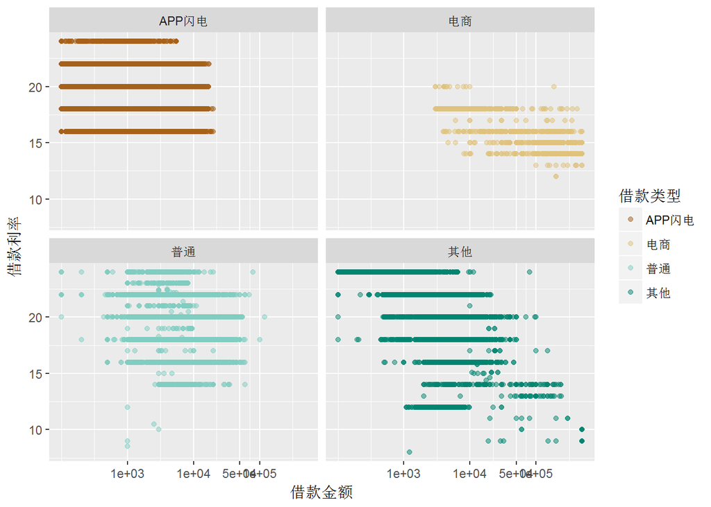

结论：  
APP闪电借款类型的借款利率全部在16%以上。借款金额以小额，万元以内为主。  
电商借款类型的借款利率主要集中在14%-16%，借款利率几乎全部在18%以下。借款金额以较大额，万元以上为主。  
**6**

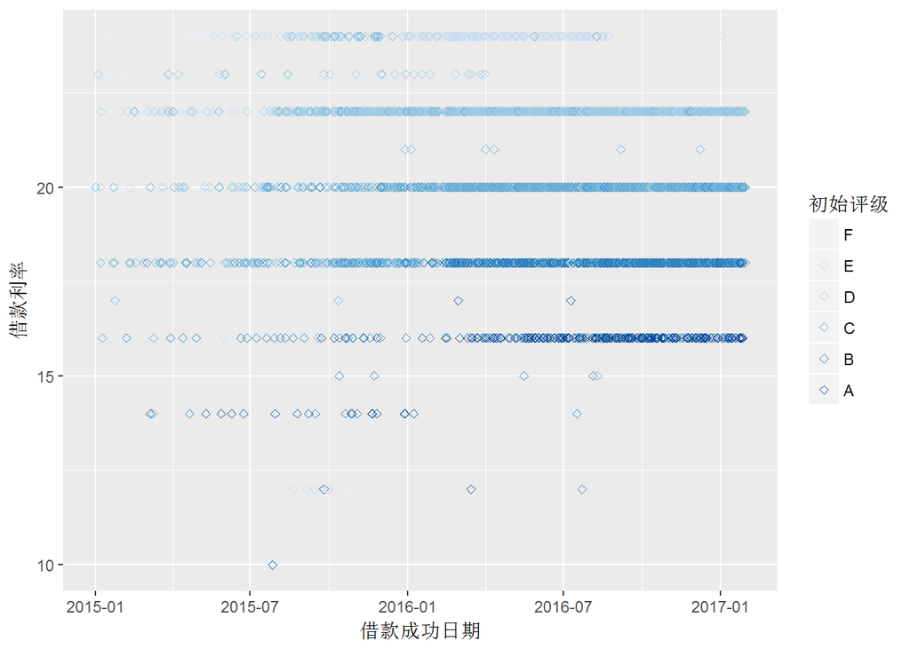

明显看出，随着初始评级的提高，利率降低。随着时间的推移，在相同初始评级的情况下，借款利率的变化如下图。

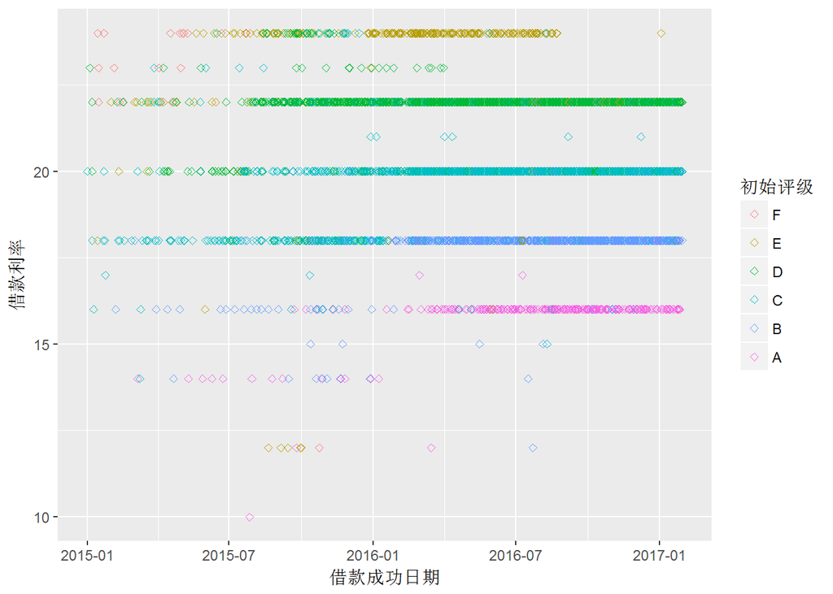

结论：  
通过抽取少量数据，能明显看出随着时间的推移，在相同初始评级的情况下，借款利率会在某个时刻上浮2%。  
初始评级是C、D、E、F借款人的借款利率，大约在2015年7月左右上浮2%。  
初始评级是A、B借款人的借款利率，大约在2016年1月左右上浮2%。

## 创建模型

```
##
## Calls:
## m1: lm(formula = loan_interest_rate ~ initial_rating, data = lc)
## m2: lm(formula = loan_interest_rate ~ initial_rating + loan_amount,
##     data = lc)
## m3: lm(formula = loan_interest_rate ~ initial_rating + loan_amount +
##     loan_type, data = lc)
## m4: lm(formula = loan_interest_rate ~ initial_rating + loan_amount +
##     loan_type + loan_period, data = lc)
##
## ===========================================================================================
##                                  m1              m2              m3              m4
## -------------------------------------------------------------------------------------------
##   (Intercept)                   20.025***       20.087***       20.104***       19.750***
##                                 (0.004)         (0.004)         (0.005)         (0.007)
##   initial_rating: .L            -5.127***       -5.087***       -5.102***       -5.038***
##                                 (0.014)         (0.014)         (0.014)         (0.014)
##   initial_rating: .Q            -2.324***       -2.322***       -2.337***       -2.315***
##                                 (0.013)         (0.013)         (0.013)         (0.013)
##   initial_rating: .C             1.128***        1.115***        1.105***        1.054***
##                                 (0.010)         (0.010)         (0.010)         (0.010)
##   initial_rating: ^4            -0.258***       -0.279***       -0.283***       -0.286***
##                                 (0.006)         (0.006)         (0.006)         (0.006)
##   initial_rating: ^5             0.003          -0.009*          0.006           0.042***
##                                 (0.004)         (0.004)         (0.004)         (0.004)
##   loan_amount                                   -0.000***       -0.000***       -0.000***
##                                                 (0.000)         (0.000)         (0.000)
##   loan_type: 电商/APP闪电                                       -2.035***       -1.848***
##                                                                 (0.031)         (0.031)
##   loan_type: 普通/APP闪电                                       -0.018***       -0.021***
##                                                                 (0.004)         (0.004)
##   loan_type: 其他/APP闪电                                       -0.114***       -0.109***
##                                                                 (0.004)         (0.004)
##   loan_period                                                                    0.036***
##                                                                                 (0.001)
## -------------------------------------------------------------------------------------------
##   R-squared                      0.771           0.778           0.782           0.784
##   adj. R-squared                 0.771           0.778           0.782           0.784
##   sigma                          0.847           0.835           0.828           0.823
##   F                         221709.350      192124.356      130690.371      119310.236
##   p                              0.000           0.000           0.000           0.000
##   Log-likelihood           -411779.916     -406803.188     -404219.896     -402385.984
##   Deviance                  235911.635      228871.862      225300.920      222799.729
##   AIC                       823573.833      813622.376      808461.793      804795.968
##   BIC                       823648.750      813707.996      808579.520      804924.397
##   N                         328551          328551          328551          328551
## ===========================================================================================
```

# ——多变量分析

### 选项：你是否创建过数据集的任何模型？讨论你模型的优缺点。

①loan_success_date和whether_the_first_bid都能对决定系数在之前的基础上产生0.002的影响，模型针对借款人找出借款利率影响最大的因素，但由于借款成功日期和是否首标，都是借款人在有实际借款需求时，不能自主决定的因素，所以在创建模型时没有添加。  
②total_success_loan_times和certification_summary都能对决定系数在之前的基础上产生0.001的影响，影响相对较小，在创建模型时没有添加。并且certification_summary与initial_rating相关性很高，可能并不线性独立，不适合添加入模型。  
③模型中，initial_rating初始评级的决定系数最高，达0.771，是对借款利率影响最大的因素。  
④l模型中，loan_amount借款金额的决定系数0.007。  
⑤l模型中，loan_type借款类型的决定系数0.004。  
⑥l模型中，loan_period借款期限的决定系数0.002。  
——

# ——定稿图与总结

### 绘图一

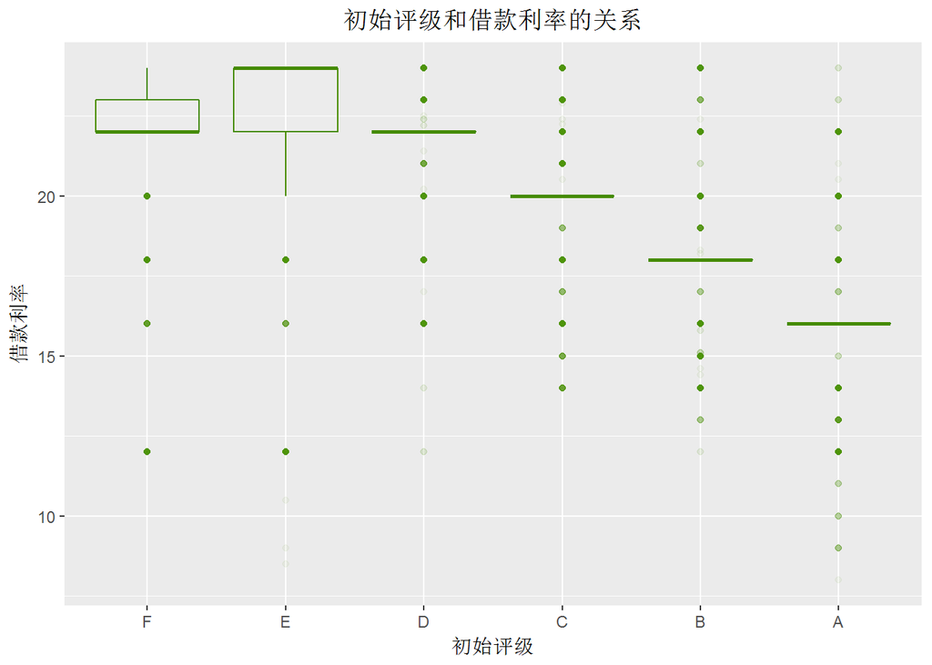

### 描述一

结论：大部分的情况下，初始评级越低，借款利率越高。

### 绘图二

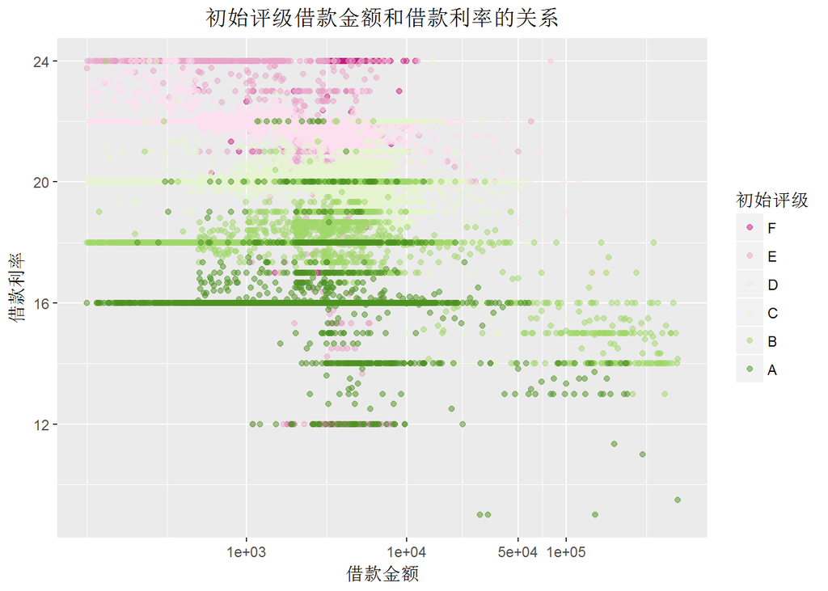

### 描述二

结论：  
随着借款金额的增大，借款利率降低。初始评级越高，借款利率越低。  
初始评级为A、B的借款人，借款金额在超过5万元左右时，利率会下降约2%-3%。  
初始评级为C、D、E、F的借款人，借款金额在超过5万元的借款人数量比较少，估计可能的原因是信用评级不够高，相对比较大金额的借款成功率下降。由于数据点较少，利率在借款金额超过5万元时，会下降约2%-3%的变化趋势不明显。

### 绘图三

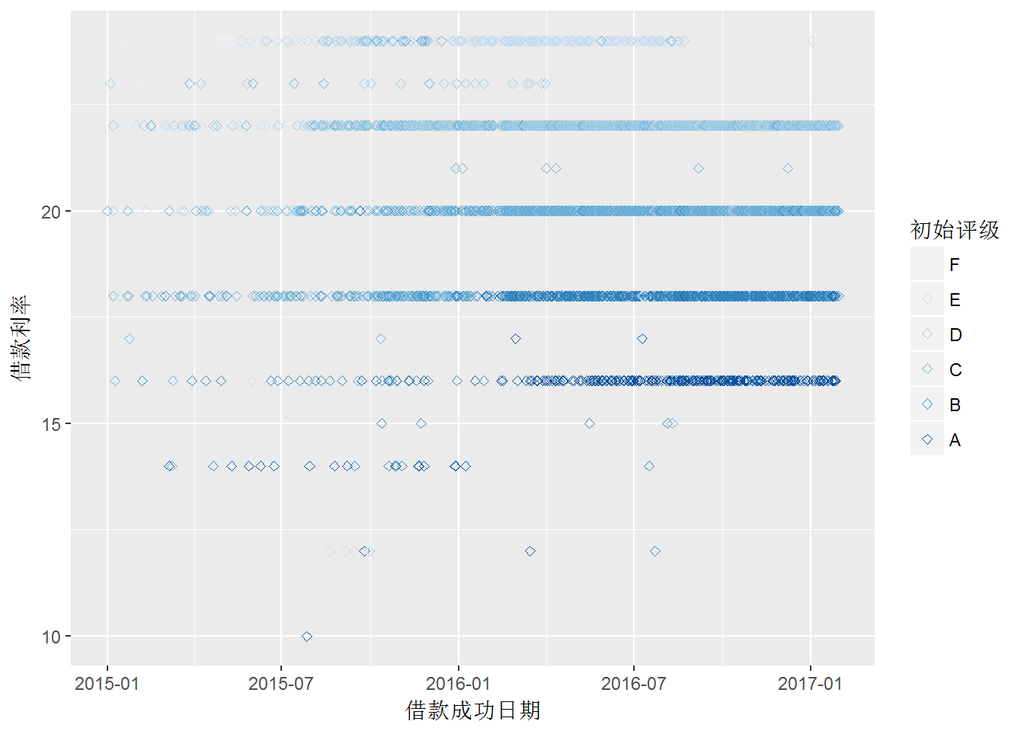

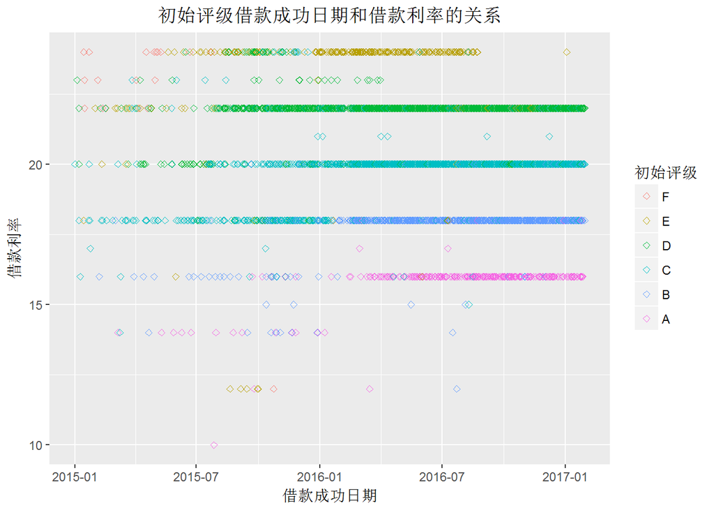

### 描述三

结论：  
通过抽取少量数据，能明显看出随着时间的推移，在相同初始评级的情况下，借款利率会在某个时刻上浮2%。  
初始评级是C、D、E、F借款人的借款利率，大约在2015年7月左右上浮2%。  
初始评级是A、B借款人的借款利率，大约在2016年1月左右上浮2%。

## 建议借款客户尽量多的完成认证，在金额和期限允许的情况下，从电商平台借款。

## 根据lcis数据框，研究以下问题：

1.标当前状态为”逾期中“的标有什么特点。哪个特点与逾期标相关性最强。

```
##    ListingId           借款金额         借款期限        借款利率
##  Min.   :  106452   Min.   :   100   Min.   : 3.00   Min.   : 9.00
##  1st Qu.: 8579950   1st Qu.:  2500   1st Qu.:10.00   1st Qu.:18.00
##  Median :11650691   Median :  4000   Median :12.00   Median :20.00
##  Mean   :12218393   Mean   :  8160   Mean   :10.82   Mean   :19.19
##  3rd Qu.:16022510   3rd Qu.:  7000   3rd Qu.:12.00   3rd Qu.:20.00
##  Max.   :32585705   Max.   :500000   Max.   :24.00   Max.   :24.00
##
##     借款成功日期     初始评级          借款类型    是否首标
##  2016/1/31: 132   C      :3935   APP闪电   :3026   否:7515
##  2016/7/28: 111   B      :3012   电商      : 135   是:2084
##  2016/2/28: 105   D      :1250   普通      :3354
##  2016/1/28: 103   A      : 775   其他      :3078
##  2016/4/30: 100   AA     : 317   应收安全标:   6
##  2016/1/27:  99   E      : 291
##  (Other)  :8949   (Other):  19
##       年龄       性别            手机认证          户口认证
##  Min.   :19.00   男:6740   成功认证  :5006   未成功认证:8760
##  1st Qu.:25.00   女:2859   其他      :   0   成功认证  : 839
##  Median :28.00             未成功认证:4593   本科      :   0
##  Mean   :29.68             未婚      :   0   初中及以下:   0
##  3rd Qu.:33.00             已婚      :   0   大专      :   0
##  Max.   :56.00                               高中      :   0
##                                              (Other)   :   0
##        视频认证          学历认证          征信认证          淘宝认证
##  成功认证  :1042   成功认证  :4019   成功认证  : 580   成功认证  :  48
##  未成功认证:8557   未成功认证:5580   未成功认证:9019   未成功认证:9551
##
##
##
##
##
##  历史成功借款次数 历史成功借款金额   总待还本金       标当前状态
##  1      :2319     0      :2084     Min.   :     0   逾期中 :9599
##  0      :2084     3000   : 302     1st Qu.:     0   0      :   0
##  2      :1515     1000   : 210     Median :  2985   0.03   :   0
##  3      : 936     5000   : 173     Mean   :  4547   0.05   :   0
##  4      : 831     3500   : 162     3rd Qu.:  5964   0.06   :   0
##  5      : 608     6000   : 154     Max.   :637451   0.07   :   0
##  (Other):1306     (Other):6514                      (Other):   0
```

从摘要来看，逾期标并没有明显的区别于其它标的特点。

2.如果投资收益=已还利息+待还利息，标当前状态为“已还清”的标，则收益率高的标有什么特点。

```
##    ListingId           借款金额         借款期限         借款利率
##  Min.   :  131605   Min.   :   100   Min.   : 2.000   Min.   :10.0
##  1st Qu.: 4180951   1st Qu.:  2964   1st Qu.: 6.000   1st Qu.:18.0
##  Median :10290391   Median :  4250   Median :12.000   Median :20.0
##  Mean   :10267949   Mean   :  7532   Mean   : 9.315   Mean   :19.1
##  3rd Qu.:13637540   3rd Qu.:  7500   3rd Qu.:12.000   3rd Qu.:20.0
##  Max.   :32070299   Max.   :500000   Max.   :24.000   Max.   :24.0
##
##     借款成功日期      初始评级           借款类型     是否首标
##  2015/8/28:  814   C      :21175   APP闪电   :12874   否:45144
##  2016/6/9 :  706   B      :20315   电商      :  489   是: 9469
##  2015/7/3 :  660   D      : 8963   普通      :26081
##  2015/9/11:  602   A      : 2814   其他      :15169
##  2016/6/14:  542   E      :  781   应收安全标:    0
##  2016/1/5 :  500   AA     :  509
##  (Other)  :50789   (Other):   56
##       年龄      性别             手机认证           户口认证
##  Min.   :18.0   男:36849   成功认证  :34012   未成功认证:48548
##  1st Qu.:25.0   女:17764   其他      :    0   成功认证  : 6065
##  Median :28.0              未成功认证:20601   本科      :    0
##  Mean   :29.5              未婚      :    0   初中及以下:    0
##  3rd Qu.:33.0              已婚      :    0   大专      :    0
##  Max.   :56.0                                 高中      :    0
##                                               (Other)   :    0
##        视频认证           学历认证           征信认证
##  成功认证  : 6244   成功认证  :26918   成功认证  : 2574
##  未成功认证:48369   未成功认证:27695   未成功认证:52039
##
##
##
##
##
##        淘宝认证     历史成功借款次数 历史成功借款金额   总待还本金
##  成功认证  :  227   1      :10780    0      : 9469    Min.   :     0
##  未成功认证:54386   0      : 9469    3000   : 1864    1st Qu.:     0
##                     2      : 9089    5000   : 1010    Median :  3649
##                     3      : 7332    6000   :  815    Mean   :  4547
##                     4      : 5459    7000   :  806    3rd Qu.:  6690
##                     5      : 4170    4000   :  735    Max.   :254966
##                     (Other): 8314    (Other):39914
##    标当前状态    投资年化收益率
##  已还清 :54613   Min.   :0.1000
##  0      :    0   1st Qu.:0.1060
##  0.03   :    0   Median :0.1160
##  0.05   :    0   Mean   :0.1218
##  0.06   :    0   3rd Qu.:0.1301
##  0.07   :    0   Max.   :1.8420
##  (Other):    0
```

# ——反思

①两个变量分析与多个变量分析，有可能得出不同结论，各个因素之间共同作用，对待分析变量产生影响。  
②单独的因素，在不同的变量阶段，也可能有完全相反的趋势。  
③拟合曲线在没有对x取sqrt或者log10的情况下，趋势很容易受特殊分布值的影响，导致趋势不准确。  
④尽量用客观描述的表达方式。  
分析必须严谨，可以推测，不能随便给出推论。更不能随便给出因果关系，相关性不等于因果。  
⑤分析过程中做的重要决定，分析过程中所遇到的挫折与成功。  
分析过程中，遇到不管写多简单的代码，ggplot也画不出图。最后经多次测试，是使用中文列名识别的原因，多次尝试解决方法，包括reviewer给出博客中的方法，都没有解决。自己估计有可能是Windows7安装系统非正版的原因。过程中都想过，再不行要改做wine的项目了，但是对贷款数据集比较感兴趣，通过把中文列名改为英文列名，暂时可以继续做项目。 ⑥对这个数据的未来拓展工作提供了至少一个提议或问题。比如对于这个数据，我们还可以进行什么更近一步的分析工作呢？或者你还能够对这个数据提出什么问题？  
我觉得可以通过对lcis数据框的进一步分析及可视化，了解投资人的最佳投资策略。